# How Caffeine, Bedtime, and Wakings Affect Sleep Quality

## Introduction: Who needs to sleep when you can have coffee and doomscroll?

How many college students actually sleep properly? Sleep deprivation has long been a problem that affects the majority of people. A quick Google search easily shows that hundreds and thousands of articles and research papers on studies with sleep quality and teens or college students.

And….. I have been guilty of having poor sleep patterns for years now. Whether it be sleeping on time, getting enough sleep and avoiding screens right before bed, I am the epitome of inconsistency and poor sleeping habits (you’ll see this soon!).

As this is something I’ve been struggling with for quite a while now, I had already been actively collecting data related. I wear a watch to sleep every night that gives me some stats on when I went to bed and how long I slept for, as well as some indication of how many times I woke up throughout the night. It even gives me a score for how well I slept but I think the coding must’ve gone wrong because 80% of the times I just get a score of 70 - 80. Even when I woke up and physically felt very unrefreshed. As a result of my poor sleeping habits, I was also trying to get my coffee addiction and over-reliance under control. So I had been logging my caffeine intakes as well.

So for this project, I decided to investigate this matter a little more. I wanted to find out what things were influencing the quality of my sleep and if there were any behavioural patterns I could pick up on to consciously make a change for the better.

### How was the data collected?

As mentioned before, a lot of the aspects that I wanted to investigate were already recorded in various apps and notes. So all I did was compile them together by putting them in my google form to collect data. I recorded down:

- the date
- I rated the quality of my sleep
- recorded how many hours I slept for
- how many times I woke up throughout the night
- how much caffeine I drank the next day
- and many other various data points, that were not used in the following analysis

Hopefully by looking at this data and plotting various ones against each other, I would be able to find what’s hurting my sleep, so I can make small changes and hopefully start getting more consistent rest!

## Sleep Duration by days of the week

I was curious to find out if I was sleeping less on particular days of the week. As we know, assignments for courses are often due on Fridays or Saturdays. I personally have a lot of activities happening on Thursday, Friday and Saturday as well. So I plotted my sleep duration against the days of the week to see if there was any significant difference. This was the plot:

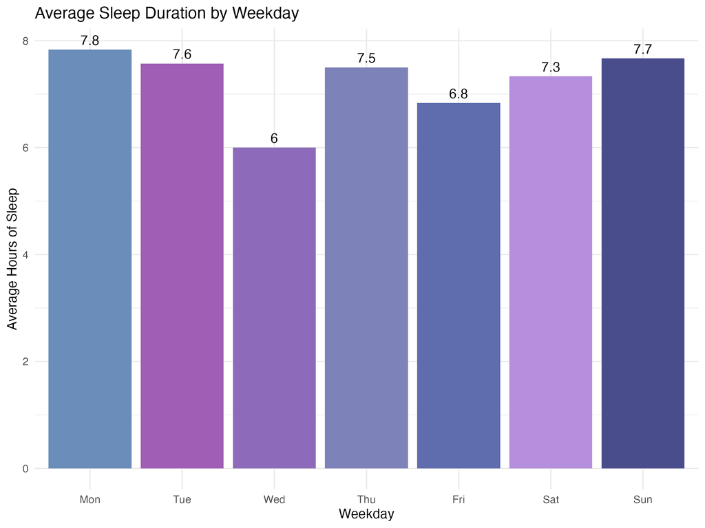

It turns out, I sleep **least on Wednesdays**, only around 6 hours! I sleep the most on *Sundays* and *Mondays* as well, which makes sense, as my *Sundays* are the most chill, and on *Mondays* I get to sleep in as I don’t have morning lectures. Meanwhile, *Wednesdays*, *Fridays* and *Saturdays* are the typical assignment/project/quiz/lab due days, so I’m clearly staying up a bit more on those nights and getting less sleep.

From this, I have recognised that I should try do a bit more of the work before those deadline days, perhaps on *Sundays* and *Mondays*, so that I can take some burden off *Wednesdays*. I will also know to watch out on *Wednesday* nights in particular to try and get to bed earlier so I can get more sleep in.

## Do wake-ups matter, or is it all about the sleep duration?

The next thing I plotted was my *sleep quality*, against my *sleep duration*, against *times woken up during nighttime*. I thought that *sleep duration* and *disturbances* were definitely going to be big contributors to my sleep quality so I wanted to put them together in one plot. I used a scatterplot to help show the 3 aspects.

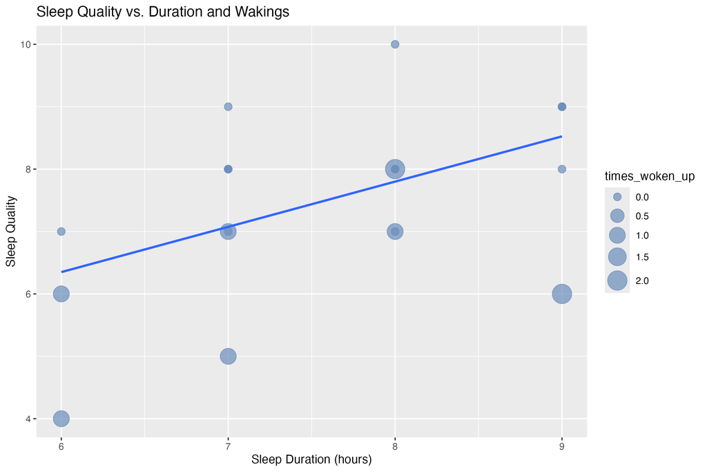

So the *sleep duration* is displayed on the x-axis in hours, and the *sleep quality* was rated from 1 - 10 on the y-axis. I used dots to show *the number of times I woke up* for that particular sleep. The bigger the dot, the more I woke up that night.

The trend line definitely shows a **positive correlation** between *sleep quality* and *sleep duration*. So be reminded that you should definitely aim for around 8 to 9 hours of sleep every night.

## Is my rating even accurate?

From the last plot we saw that the *sleep quality* improved with *sleep duration* being hours from 6 - 9. But like I said, the *ratings* were me picking a number between 1 to 10 after I woke up. It was based entirely on how I felt. Perhaps I felt like I didn’t sleep well because my sister shouted in my ear to wake me up. Maybe I unintentionally rated it higher because it was a nice sunny day outside. As it was kind of subjective, it may not be accurate.

To counter this, I decided to use something that was a little more objective - the *caffeine intakes*. As I was trying to cut down on coffee intakes, I would only drink on days when I felt really groggy and needed something to pick me up. I thought the choice of how many espresso shots I wanted could be a good indication of how tired I was feeling after the sleep. So I plotted my *sleep quality ratings* against my *coffee intake*.

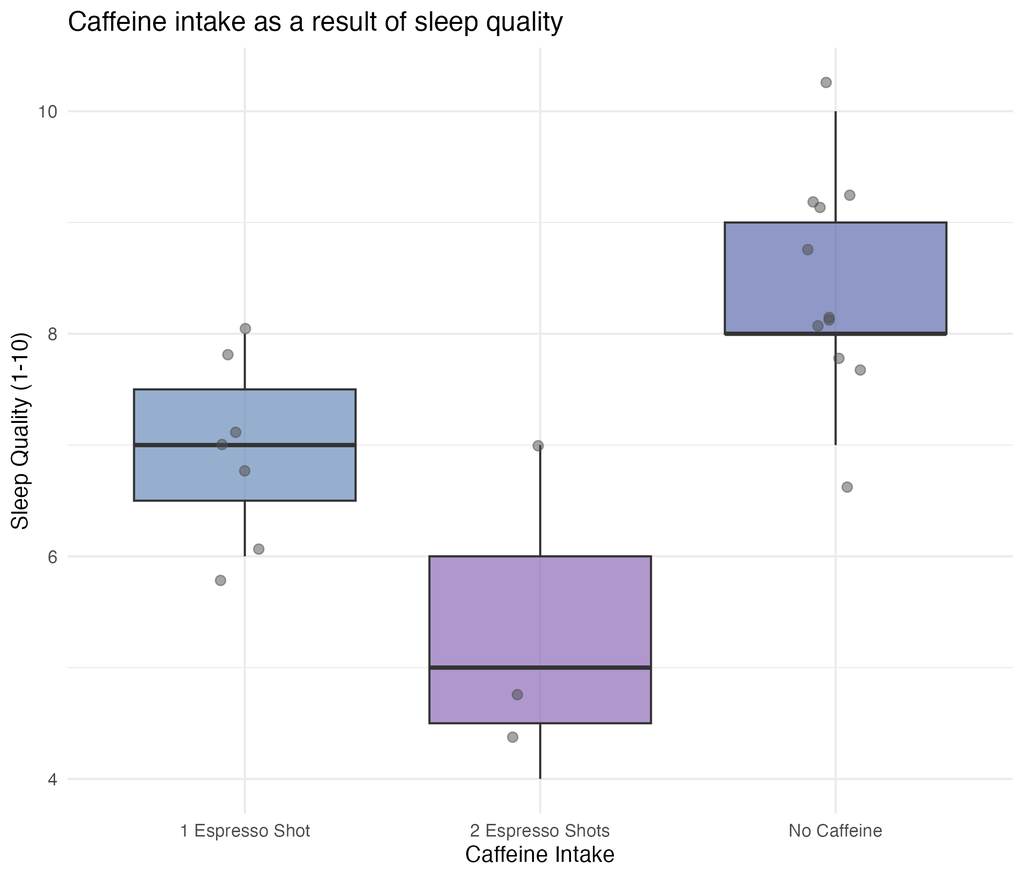

So the box plot shows *sleep quality* grouped by *caffeine intake* (no caffeine, 1 espresso shot, 2 espresso shots). We can see that there appears to be a significant difference between the average ratings.

- *No caffeine* = better sleep quality rating
- *1 espresso* = decent sleep rating, around 7/10
- *2 espressos* = poor sleep quality rating

This is a good sign that I was being decently objective with my *sleep rating*. When I thought I had a poor night sleep, I did drink more coffee to help me get through the day. And when I slept well and rated well, I went coffee-free. The boxes don’t overlap each other and the averages are clearly quite far from each other.

## Conclusion and key takeaways

Wow these were some interesting trends! I realised that:

- **Deadline days were the biggest sleep killers**
- So called ‘sleep tracking’ apps may not be as accurate as we think
- Sleep duration matters! I should aim to get around 8 - 9 hours of sleep every night

A good way to continue tracking my habits could even be just to monitor coffee intakes. It may not be realistic to keep observational logs everyday and continue to monitor and draw plots on sleep patterns, but since I know that the more coffee I drink indicates that I didn’t sleep well, I could just look at how much coffee I was drinking. If I can stay away from coffee for an entire week, that’s probably a good sign that I have been sleeping well.

I hope you found my investigation interesting and learned something from it as well! To whoever is reading, I hope you have a wonderful sleep tonight!